# Assessing the Relationship Between Life Expectancies of Countries and Being Hit Hard by COVID-19

Data Analysis and Visualization in R // Spring 2022 // Hunter College

Reina Li

## Assignment Details

Attempt a preliminary answer to the following question using between one and five charts: Over the course of the pandemic, were countries with lower life expectancies hit harder by COVID-19 than countries with higher life expectancies? Submit your answer in an annotated RMarkdown file with code and explanation for each chart created and the summary of the findings of your study. All in the same file. Do not use the rstudioapi library, as it will not work with RMarkdown. To create the charts use the provided datasets from: World Bank for life expectancy, Johns Hopkins for COVID-19, UN for country population and country code data. You may add further datasets if necessary, but the number of charts are limited. Only provide charts that help to answer the question directly.

## Introduction

According to the [World Health Organization](https://www.who.int/health-topics/coronavirus#tab=tab_1), COVID-19 is an infectious disease caused by the SARS-CoV-2 virus. Most people infected with the virus will experience mild to moderate respiratory illness and recover without requiring special treatment. However, some will become seriously ill and require medical attention. Older people and those with underlying medical conditions like cardiovascular disease, diabetes, chronic respiratory disease, or cancer are more likely to develop serious illness. Anyone can get sick with COVID-19 and become seriously ill or die at any age.

Life expectancy is a measure of premature death and refers to the number of years a person can expect to live. According to [The World Bank](https://data.worldbank.org/indicator/SP.DYN.LE00.IN), the global life expectancy in 2019 was 72.747 years.

The purpose of this analysis is to see if there is a relationship between life expectancy of a country and the amount of COVID-19 deaths.

## Analysis Question

**1. Over the course of the pandemic, were countries with lower life expectancies hit harder by COVID-19 than countries with higher life expectancies?**

## Description of the Data

I will use the provided data sets from: [The World Bank](https://data.worldbank.org/indicator/SP.DYN.LE00.IN) for life expectancy, [John Hopkins](https://coronavirus.jhu.edu/) for COVID-19, [UN](https://population.un.org/wup/Download/) for country population and country code, and [opendatasoft](https://public.opendatasoft.com/explore/dataset/countries-codes/table/) for country code to create one to five data visualizations to answer the analysis question.

Before I start writing any code, I need to define some things:

- What is considered being “hit hard” by COVID-19?
- What is considered “low” life expectancy and “high” life expectancy?

[John Hopkins](https://coronavirus.jhu.edu/) provides data on COVID-19 confirmed cases and deaths. But for this analysis, I will be only looking at the COVID-19 deaths. So, I will evaluate how much a country was “hit hard by COVID-19” by comparing the amount of COVID-19 deaths of each country to the global median COVID-19 deaths. The reason why I am performing the comparison using the median instead the mean is because the there may be outliers that can skew the data. If a country’s COVID-19 deaths count is less than the median value of COVID-19 deaths, then it will be considered as “not hit as hard.” If a country’s COVID-19 deaths count is greater than or equal to the median value of COVID-19 deaths, then it will be considered as “hit hard.”

For the life expectancy data set, I will be looking at a country’s 2019 life expectancy at birth, in years. To determine if a country has “high” or “low” life expectancy, I will compare it with the global life expectancy from 2019, which is 72.747 years. If a country’s life expectancy is less than the global value, then it will be considered as “low life expectancy.” If a country’s life expectancy is greater than or equal to the global value, then it will be considered as “high life expectancy.”

## Data Preparation

Before I can make data visualizations, the data sets have to be imported, cleaned, and transformed. So first, I need to load the libraries.

```r
# Libraries --------------------------------------------------------------------
library(tidyverse)
library(janitor)
library(lubridate)
library(readxl)
```

Next, I need to import the data sets into the environment. *Please note that I put all of the data set files in the same folder.*

For the Life Expectancy and Population/Country Code data sets, I need to edit the data sets before importing it; I removed the first few rows of the data set, so the new data set would start from the header row.

```r
# Import the data --------------------------------------------------------------
# World Bank for life expectancy
lifeExpectancy <- read.csv(file = 'API_SP.DYN.LE00.IN_DS2_en_csv_v2_3852476.csv', fileEncoding="UTF-8-BOM")

# John Hopkins for COVID-19
covidGlobalData <- read.csv(file = 'time_series_covid19_deaths_global.csv')
covidUSData <- read.csv(file = 'time_series_covid19_deaths_US.csv')

# UN for country population and country code
population_countryCode <- read_excel("WUP2018-F05-Total_Population.xls")

# opendatasoft for country code
countrycodes <- read_excel('countries-codes.xlsx')
```

The data sets are now imported into the environment. After checking out the structures of the data sets, not all of the data will be used. That is why it is important to tidy, manipulate, and join the data sets.

```r
# Tidy the data ----------------------------------------------------------------
lifeExpectancy_Data <- lifeExpectancy %>%
  # Keep the country name, country code, and the 2019 life expectancy
  select(Country.Name, Country.Code, X2019) %>%
  # Make a new column that states if the country has high or low life expectancy
  # high life expectancy: value >= 72.747
  # low life expectancy: value < 72.747
  mutate(Life_Expectancy = ifelse(test = (X2019 >= 72.747),
                           yes = "High Life Expectancy",
                           no = "Low Life Expectancy")) %>%
  # Rename life expectancy column
  rename(life_expectancy_years = X2019)

covidGlobal_Deaths <- covidGlobalData %>%
  # Keep the country name and the cumulative amount of COVID-19 deaths
  select(Country.Region, X4.3.22) %>%
  # Rename country name column
  rename(country_name = Country.Region) %>%
  # Group by country
  group_by(country_name) %>%
  # Find the total cumulative amount of COVID-19 deaths for countries
  summarize(X4.3.22 = sum(X4.3.22)) %>%
  # Rename COVID-19 deaths column
  rename(cumulative_deaths = X4.3.22)

covidUS_Deaths <- covidUSData %>%
  # Keep the country name and the cumulative amount of COVID-19 deaths
  select(Country_Region, X4.3.22) %>%
  # Rename country name column
  rename(country_name = Country_Region) %>%
  # Group by country
  group_by(country_name) %>%
  # Find the total cumulative amount of COVID-19 deaths for countries
  summarize(X4.3.22 = sum(X4.3.22)) %>%
  # Rename COVID-19 deaths column
  rename(cumulative_deaths = X4.3.22) %>%
  # Rename US to United States
  mutate(country_name = ifelse(country_name == "US", "United States of America", country_name))

# Combine Global and US COVID-19 Deaths data
covid_Deaths <- rbind(covidGlobal_Deaths, covidUS_Deaths) %>%
  # Make a new column that states if the country was hit hard by COVID-19
  # Calculate the median count of COVID-19 deaths
  # median(covid_Deaths$cumulative_deaths)
  # The median is 3136 deaths.
  # hit hard: value >= 3136
  # not hit as hard: value < 3136
  mutate(Hit_Hard_By_COVID19 = ifelse(test = (cumulative_deaths >= 3136),
                           yes = "Hit Hard",
                           no = "Not Hit Hard"))

population_countryCode_Data <- population_countryCode %>%
  # Keep the country name, country code, and the 2020 population
  select(Country, Country_code, X2020) %>%
  # Rename the population column
  rename(population2020 = X2020)

# Join the data frames
population_and_country_codes <- countrycodes %>%
  # The country code column needs to be converted from character into integer
  mutate_at(4, as.numeric) %>%
  # Inner join on the country code
  inner_join(population_countryCode_Data, by = c("ONU" = "Country_code"))

df <- population_and_country_codes %>%
  # Keep the country code, country name and 2020 population
  select(ISO3, ONU, Country, population2020) %>%
  # Inner join on the country code
  inner_join(lifeExpectancy_Data, by = c("ISO3" = "Country.Code")) %>%
  inner_join(covid_Deaths, by = c("Country" = "country_name")) %>%
  # Keep the country code, country name, 2020 population, 2019 life expectancy, indication of low/high life expectancy, cumulative COVID-19 deaths, and indication of being hit hard or not by COVID-19
  select(ISO3, ONU, Country, population2020, life_expectancy_years, Life_Expectancy, cumulative_deaths, Hit_Hard_By_COVID19)
```

## Analysis

Now that the data set is all tidied up, it is time to create the data visualizations that will help answer the analysis question directly.

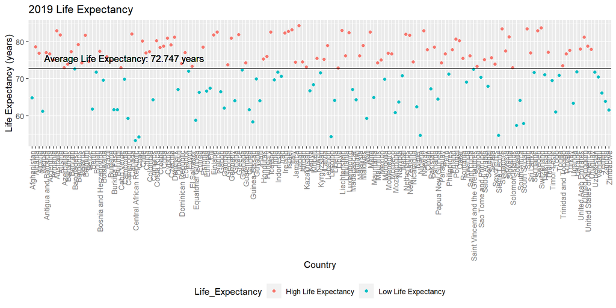

```r
# Create data visualizations ---------------------------------------------------
h_line <- 72.747

ggplot(data = subset(df, !is.na(life_expectancy_years)), aes(x = Country, y = life_expectancy_years)) +
  geom_point(aes(colour = Life_Expectancy)) +
  geom_hline(aes(yintercept = h_line)) +
  geom_text(aes(0, h_line, label = "Average Life Expectancy: 72.747 years", vjust = -1, hjust = -0.1)) +
  labs(title = "2019 Life Expectancy",
       x = "Country",
       y = "Life Expectancy (years)") +
  theme(legend.position = "bottom",
        axis.text.x = element_text(angle = 90, hjust = 1, vjust = 0.5, colour = 'gray50'))
```

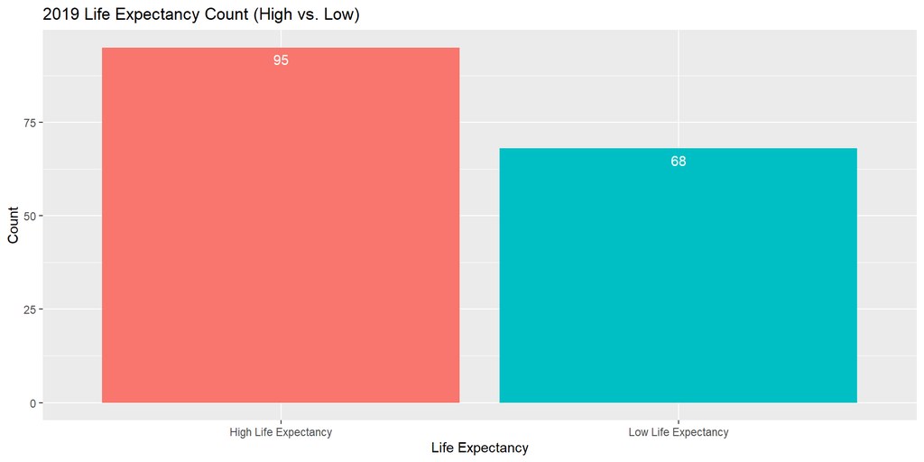

```r
# Create data visualizations ---------------------------------------------------
ggplot(data = subset(df, !is.na(life_expectancy_years)), aes(x = factor(Life_Expectancy))) +
  geom_bar(stat="count", aes(fill = Life_Expectancy)) +
  geom_text(stat = "count", aes(label = after_stat(count)), vjust = 1.6,
            color = "white") +
  labs(title = "2019 Life Expectancy Count (High vs. Low)",
       x = "Life Expectancy",
       y = "Count") +
  theme(legend.position = "none")
```

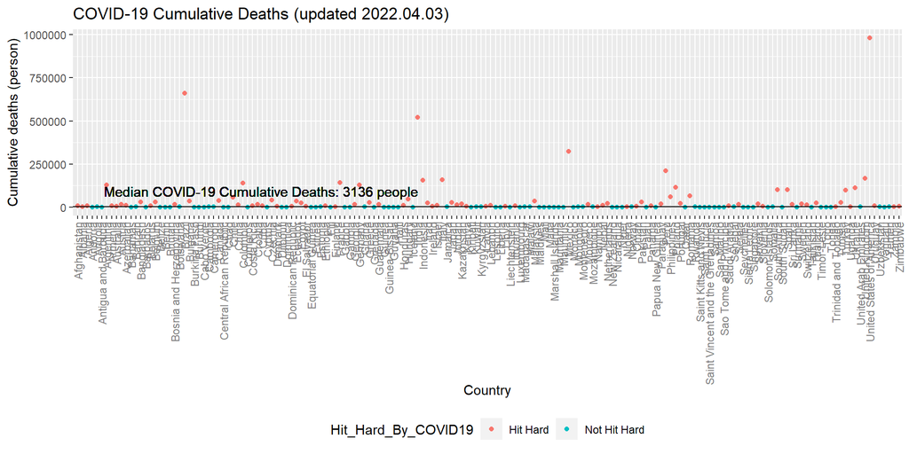

```r
# Create data visualizations ---------------------------------------------------
h_line <- 3136

ggplot(data = subset(df, !is.na(cumulative_deaths)), aes(x = Country, y = cumulative_deaths)) +
  geom_point(aes(colour = Hit_Hard_By_COVID19)) +
  geom_hline(aes(yintercept = h_line)) +
  geom_text(aes(0, h_line, label = "Median COVID-19 Cumulative Deaths: 3136 people", vjust = -1, hjust = -0.1)) +
  labs(title = "COVID-19 Cumulative Deaths (updated 2022.04.03)",
       x = "Country",
       y = "Cumulative deaths (person)") +
  theme(legend.position = "bottom",
        axis.text.x = element_text(angle = 90, hjust = 1, vjust = 0.5, colour = 'gray50'))
```

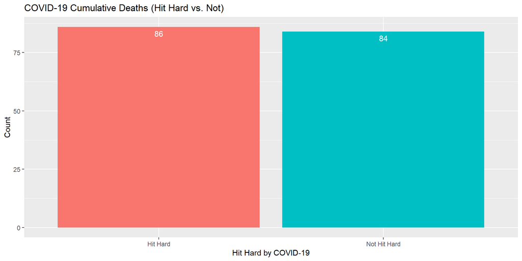

```r
# Create data visualizations ---------------------------------------------------
ggplot(data = subset(df, !is.na(cumulative_deaths)), aes(x = factor(Hit_Hard_By_COVID19))) +
  geom_bar(stat="count", aes(fill = Hit_Hard_By_COVID19)) +
  geom_text(stat = "count", aes(label = after_stat(count)), vjust = 1.6,
            color = "white") +
  labs(title = "COVID-19 Cumulative Deaths (Hit Hard vs. Not)",
       x = "Hit Hard by COVID-19",
       y = "Count") +
  theme(legend.position = "none")
```

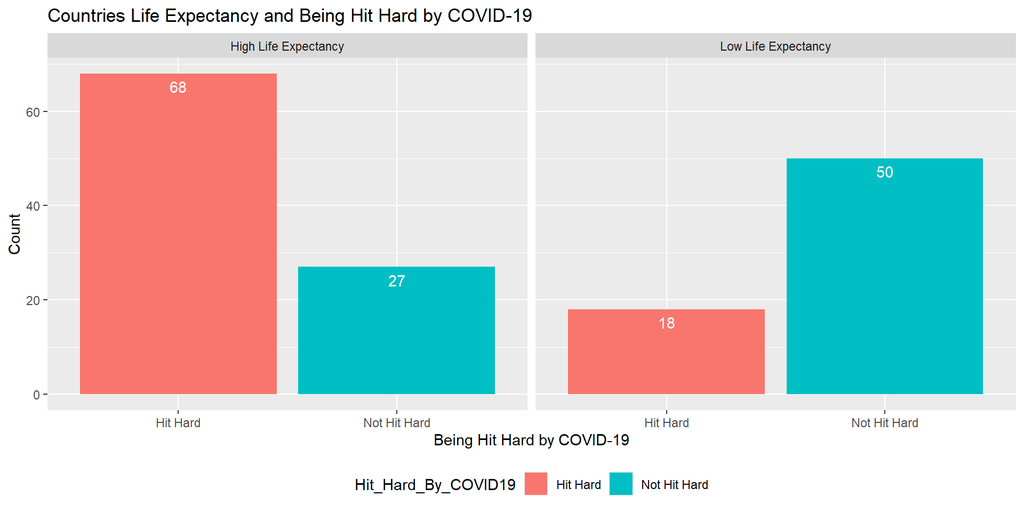

```r
# Create data visualizations ---------------------------------------------------
ggplot(data = subset(df, !is.na(life_expectancy_years)), mapping = aes(x = Hit_Hard_By_COVID19, fill = Hit_Hard_By_COVID19)) +
  geom_histogram(position = "identity", stat="count") +
    geom_text(stat = "count", aes(label = after_stat(count)), vjust = 1.6,
            color = "white") +
  facet_grid(.~Life_Expectancy) +
  labs(title = "Countries Life Expectancy and Being Hit Hard by COVID-19",
       x = "Being Hit Hard by COVID-19",
       y = "Count") +
    theme(legend.position = "bottom")
```

## Conclusion

Looking at the data visualizations, it seems like over the course of the pandemic, countries with lower life expectancies were **not** hit harder by COVID-19 than countries with higher life expectancies.